# Kiểm tra lần 2 - KDL 1

Nhóm AA

2026-06-04

**Phân công nhiệm vụ Nhóm AA:**

- **Bài tập Nhóm 1**: Phắt, Phát
- **Bài tập Nhóm 2**: Đức, Khang
- **Bài tập Nhóm 3**: Lan Anh, Bảo
- **Tổng hợp file**: Khang, Phát, Bảo

# 0. Import thư viện

```r
library(tidyr)
library(dplyr)
library(ggplot2)
```

# Bài tập Nhóm 1: Tiền xử lý dữ liệu và Khám phá phân phối (Quy mô nhỏ)

**Mục tiêu:** Sinh viên làm quen với việc làm sạch dữ liệu cơ bản trong R và thao tác với các hàm họ p và q trên phân phối liên tục.

**Bối cảnh:** Nhóm vào vai các nhà phân tích giáo dục, đánh giá thời gian hoàn thành một bài thi trắc nghiệm trực tuyến (tính bằng phút) của hàng ngàn sinh viên. Dữ liệu thô thu thập được từ hệ thống chứa nhiều lỗi do đường truyền.

## 1. Khởi tạo và Làm sạch dữ liệu

Hãy sinh ngẫu nhiên một vector gồm 5000 quan sát từ phân phối chuẩn $N(60, 15^2)$. Để giả lập lỗi hệ thống, hãy chủ động thay thế 150 giá trị ngẫu nhiên thành NA và 50 giá trị ngẫu nhiên thành số âm. Nhiệm vụ của nhóm là loại bỏ hoàn toàn các giá trị NA và các giá trị < 0. Lưu kết quả đã làm sạch vào một data frame bắt buộc mang tên là `final_data` (chứa 1 cột tên là `Time`).

```r
# Khoi tao du lieu chuan N(60, 15^2)
set.seed(42)
raw_data <- rnorm(5000, mean = 60, sd = 15)

# Gia lap loi he thong
na_indices <- sample(1:5000, 150)
raw_data[na_indices] <- NA

remaining_indices <- which(!is.na(raw_data))
neg_indices <- sample(remaining_indices, 50)
raw_data[neg_indices] <- -abs(raw_data[neg_indices]) - 1

# Loai bo NA va gia tri am
clean_data <- raw_data[!is.na(raw_data) & raw_data >= 0]

# Luu vao data frame final_data
final_data <- data.frame(Time = clean_data)
head(final_data)
```

```
##       Time
## 1 80.56438
## 2 51.52953
## 3 65.44693
## 4 69.49294
## 5 66.06402
## 6 58.40813
```

## 2. Khám phá phân phối

Tính $\bar{X}$ và $S$ của cột `Time` trong `final_data`. Vẽ đồ thị Histogram với tần suất tương đối (`freq = FALSE`), sau đó dùng `curve()` vẽ đè đường mật độ phân phối chuẩn dựa trên $\bar{X}$ và $S$ vừa tính.

```r
# Tinh trung binh mau X_bar va do lech chuan mau S
X_bar <- mean(final_data$Time)
S <- sd(final_data$Time)

cat("Trung binh mau (X_bar):", X_bar, "\n")
```

```
## Trung binh mau (X_bar): 59.72209
```

```r
cat("Do lech chuan mau (S):", S, "\n")
```

```
## Do lech chuan mau (S): 15.1202
```

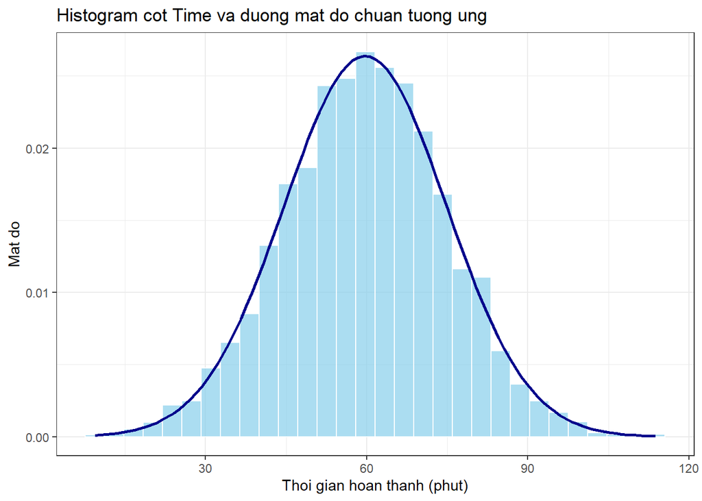

```r
# Ve Histogram tan suat tuong doi va duong mat do chuan
ggplot(final_data, aes(x = Time)) +
  geom_histogram(aes(y = after_stat(density)), bins = 30, fill = "skyblue", color = "white", alpha = 0.7) +
  stat_function(fun = dnorm, args = list(mean = X_bar, sd = S), color = "darkblue", linewidth = 1) +
  labs(title = "Histogram cot Time va duong mat do chuan tuong ung",
       x = "Thoi gian hoan thanh (phut)", y = "Mat do") +
  theme_bw()
```

## 3. Ứng dụng hàm xác suất

Giả định thời gian thi tuân theo phân phối chuẩn với tham số lấy từ mẫu. Hãy dùng hàm `pnorm()` để tính xác suất một sinh viên hoàn thành bài thi sớm hơn 45 phút.

```r
prob_early <- pnorm(45, mean = X_bar, sd = S)
cat("Xac suat hoan thanh bai thi som hon 45 phut:", prob_early, "\n")
```

```
## Xac suat hoan thanh bai thi som hon 45 phut: 0.1651101
```

## 4. Hàm phân vị (Quantile)

Ban tổ chức muốn tặng phần thưởng cho top 5% sinh viên nộp bài nhanh nhất (thời gian thấp nhất). Hãy dùng `qnorm()` để xác định mốc thời gian tối đa để nhận thưởng.

```r
time_limit <- qnorm(0.05, mean = X_bar, sd = S)
cat("Moc thoi gian toi da de nhan thuong (top 5% nhanh nhat):", time_limit, "phut\n")
```

```
## Moc thoi gian toi da de nhan thuong (top 5% nhanh nhat): 34.85157 phut
```

# Bài tập Nhóm 2: Lập trình Mô phỏng và Hệ quả CLT (Quy mô vừa)

**Mục tiêu:** Rèn luyện kỹ năng viết hàm (`function()`), kiểm chứng Định lý Giới hạn Trung tâm trên phân phối bất đối xứng, và tự code công thức khoảng tin cậy.

**Bối cảnh:** Nhóm kỹ sư đánh giá tuổi thọ của một loại cảm biến nhiệt độ công nghiệp (đơn vị: nghìn giờ). Dữ liệu này tuân theo phân phối Mũ (Exponential) bị lệch phải mạnh, với tỷ lệ hỏng hóc $\lambda = 0.2$.

## 1. Viết hàm tổng quát

Xây dựng một hàm tên `simulate_clt_exp(n, lambda, R = 5000)`. Hàm này sẽ lặp lại $R$ lần việc rút một mẫu kích thước $n$ từ phân phối Mũ, tính trung bình mẫu, và trả về một vector chứa $R$ giá trị trung bình đó.

```r
simulate_clt_exp <- function(n, lambda, R = 5000) {
  means <- replicate(R, mean(rexp(n, rate = lambda)))
  return(means)
}
```

## 2. Kiểm chứng hội tụ

Thực thi hàm với $n = 40$ và $\lambda = 0.2$. Vẽ Histogram của vector kết quả. Theo CLT, phân phối của trung bình mẫu này sẽ xấp xỉ phân phối chuẩn. Hãy vẽ đường phân phối chuẩn lý thuyết có $\mu = \frac{1}{\lambda}$ và $\sigma^2 = \frac{1}{n \lambda^2}$ đè lên Histogram để chứng minh sự khớp nhau.

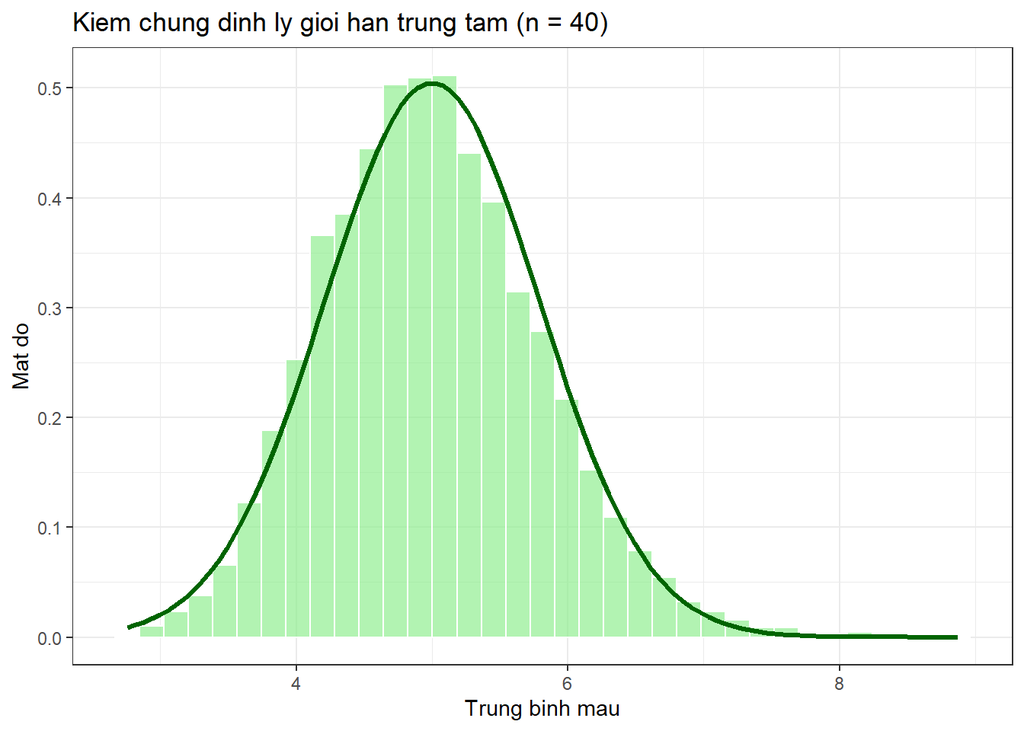

```r
n <- 40
lambda <- 0.2
R <- 5000

set.seed(42)
sim_means <- simulate_clt_exp(n = n, lambda = lambda, R = R)
sim_df <- tibble(mean_val = sim_means)

# Tinh mu va sigma ly thuyet
mu_theo <- 1 / lambda
sd_theo <- 1 / (lambda * sqrt(n))

# Ve Histogram va duong mat do ly thuyet
ggplot(sim_df, aes(x = mean_val)) +
  geom_histogram(aes(y = after_stat(density)), bins = 35, fill = "lightgreen", color = "white", alpha = 0.7) +
  stat_function(fun = dnorm, args = list(mean = mu_theo, sd = sd_theo), color = "darkgreen", linewidth = 1.2) +
  labs(title = "Kiem chung dinh ly gioi han trung tam (n = 40)",
       x = "Trung binh mau", y = "Mat do") +
  theme_bw()
```

## 3. Khoảng tin cậy cho phương sai

Trích xuất ngẫu nhiên một mẫu đơn lẻ gồm 30 quan sát từ tập mô phỏng trên. Hãy tự viết code thực thi công thức tính khoảng tin cậy 95% cho phương sai $\sigma^2$ của tổng thể dựa trên phân phối Chi-bình phương ($\chi^2$). Không dùng các package tự động.

```r
# Trich xuat ngau nhien mau 30 quan sat
set.seed(42)
sample_sensor <- rexp(30, rate = lambda)

n_sensor <- 30
df_sensor <- n_sensor - 1
var_sensor <- var(sample_sensor)

# Phan vi Chi-binh phuong
chi_lower <- qchisq(0.025, df = df_sensor)
chi_upper <- qchisq(0.975, df = df_sensor)

# Khoang tin cay 95% cho phuong sai
ci_var_lower <- (df_sensor * var_sensor) / chi_upper
ci_var_upper <- (df_sensor * var_sensor) / chi_lower

cat("Khoang tin cay 95% cho phuong sai sigma^2: [", ci_var_lower, ",", ci_var_upper, "]\n")
```

```
## Khoang tin cay 95% cho phuong sai sigma^2: [ 22.88923 , 65.21738 ]
```

## 4. Nhận xét đồ họa

Tạo một data.frame báo cáo giới hạn dưới và giới hạn trên của khoảng tin cậy phương sai vừa tính. Trực quan hóa độ rộng của khoảng này bằng việc vẽ một đường thẳng nằm ngang tương ứng trên không gian đồ thị tự do (`plot(NA, ...)`).

```r
# Khoi tao bang bao cao khoang tin cay
ci_report <- tibble(
  Chi_so = "Phuong sai cam bien",
  Can_duoi = ci_var_lower,
  Uoc_luong_diem = var_sensor,
  Can_tren = ci_var_upper
)
print(ci_report)
```

```
## # A tibble: 1 × 4
##   Chi_so              Can_duoi Uoc_luong_diem Can_tren
##   <chr>                  <dbl>          <dbl>    <dbl>
## 1 Phuong sai cam bien     22.9           36.1     65.2
```

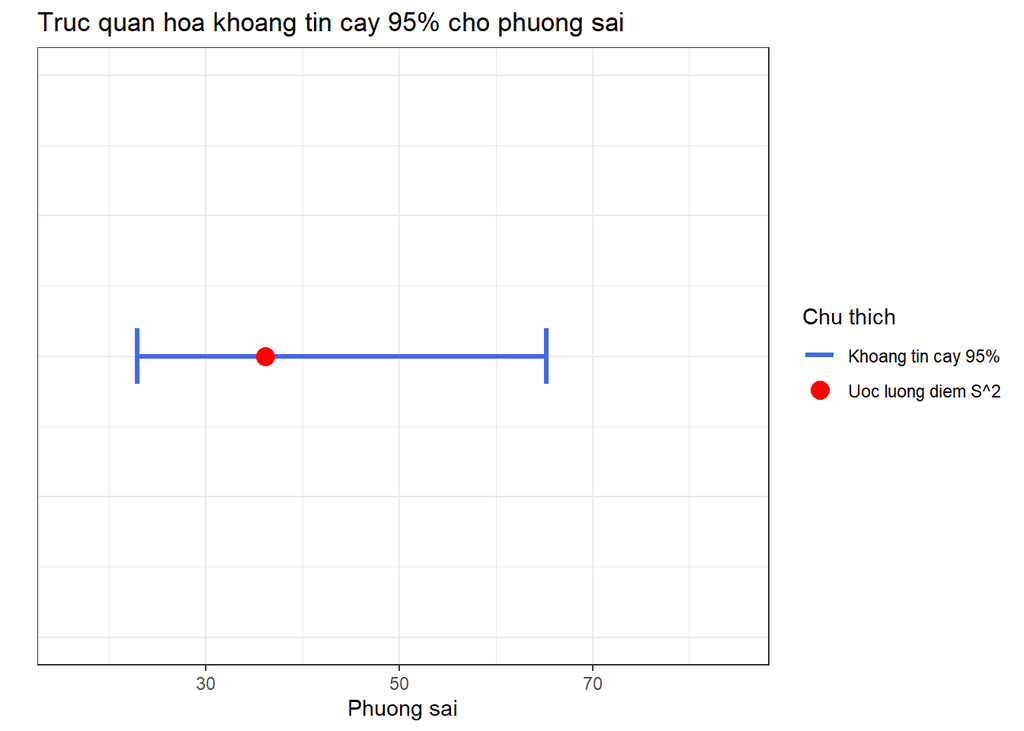

```r
# Truc quan hoa khoang tin cay
ggplot() +
  geom_errorbar(aes(y = 1, xmin = ci_var_lower, xmax = ci_var_upper, color = "Khoang tin cay 95%"),
                width = 0.1, linewidth = 1.2) +
  geom_point(aes(x = var_sensor, y = 1, color = "Uoc luong diem S^2"), size = 4) +
  scale_color_manual(values = c(
    "Khoang tin cay 95%" = "royalblue",
    "Uoc luong diem S^2" = "red"
  )) +
  xlim(ci_var_lower * 0.7, ci_var_upper * 1.3) +
  ylim(0.5, 1.5) +
  labs(title = "Truc quan hoa khoang tin cay 95% cho phuong sai",
       x = "Phuong sai", y = "", color = "Chu thich") +
  theme_bw() +
  theme(axis.text.y = element_blank(), axis.ticks.y = element_blank())
```

# Bài tập Nhóm 3 (Capstone Project): Ước lượng Điểm và Khoảng Toàn diện (Quy mô lớn)

**Mục tiêu:** Tích hợp kỹ năng giải phương trình MoM, lập trình tối ưu hóa hàm Hợp lý Cực đại (MLE), và xây dựng khoảng tin cậy phi tham số.

**Bối cảnh:** Nhóm phân tích hiệu suất hệ thống đang nghiên cứu tỷ lệ sử dụng RAM (tính bằng phần trăm, nhận giá trị từ 0 đến 1) trên một cụm máy chủ đám mây. Dữ liệu tỷ lệ phần trăm này tuân theo phân phối Beta với hai tham số hình dạng là $\alpha$ và $\beta$.

## 1. Khởi tạo dữ liệu ẩn

Sinh ra tập dữ liệu 3000 quan sát bằng lệnh `rbeta(3000, shape1 = 2, shape2 = 5)` và lưu vào cột `ram_usage` trong data frame tên là `final_data`. Trong các bước sau, nhóm phải coi $\alpha = 2$ và $\beta = 5$ là các tham số chưa biết cần đi tìm.

```r
set.seed(42)
final_data_beta <- data.frame(
  ram_usage = rbeta(3000, shape1 = 2, shape2 = 5)
)
head(final_data_beta)
```

```
##   ram_usage
## 1 0.1849358
## 2 0.3647604
## 3 0.4308070
## 4 0.3744371
## 5 0.2647604
## 6 0.6756505
```

## 2. Ước lượng Mô-men (MoM)

Viết code tính $\bar{X}$ và $S^2$ của cột `ram_usage`. Dựa vào công thức giải hệ phương trình MoM của phân phối Beta trong tài liệu, hãy lập trình tính ra hai giá trị ước lượng điểm $\hat{\alpha}^{MoM}$ và $\hat{\beta}^{MoM}$.

Công thức giải hệ phương trình MoM:
$$\hat{\alpha}^{MoM} = \bar{X} \left( \frac{\bar{X}(1-\bar{X})}{S^2} - 1
\right)$$
$$\hat{\beta}^{MoM} = (1 - \bar{X}) \left( \frac{\bar{X}(1-\bar{X})}{S^2}
- 1 \right)$$

```r
mean_beta <- mean(final_data_beta$ram_usage)
var_beta <- var(final_data_beta$ram_usage)

factor_mom <- (mean_beta * (1 - mean_beta) / var_beta) - 1
alpha_mom <- mean_beta * factor_mom
beta_mom <- (1 - mean_beta) * factor_mom

cat("Uoc luong MoM alpha:", alpha_mom, "\n")
```

```
## Uoc luong MoM alpha: 1.972854
```

```r
cat("Uoc luong MoM beta:", beta_mom, "\n")
```

```
## Uoc luong MoM beta: 4.994816
```

## 3. Ước lượng Hợp lý Cực đại (MLE)

Tự viết hàm mục tiêu `nll_beta(params, data)` trả về Negative Log-Likelihood của phân phối Beta. Cần cẩn thận sử dụng hàm `dbeta()` với đối số `log = TRUE`. Sử dụng hàm `nlminb()` để tối ưu hóa, truyền kết quả từ MoM ở câu 2 vào làm tham số khởi đầu (`start`). Phải cấu hình đối số `lower` để chặn không cho $\alpha$ và $\beta$ nhận giá trị âm hoặc bằng 0. Trích xuất và in ra kết quả $\hat{\alpha}^{MLE}$ và $\hat{\beta}^{MLE}$.

```r
# Ham negative log-likelihood cua phan phoi Beta
nll_beta <- function(params, data) {
  alpha <- params[1]
  beta <- params[2]
  if (alpha <= 0 || beta <= 0) return(Inf)
  return(-sum(dbeta(data, shape1 = alpha, shape2 = beta, log = TRUE)))
}

# Toi uu hoa bang nlminb
opt_beta <- nlminb(
  start = c(alpha_mom, beta_mom),
  objective = nll_beta,
  data = final_data_beta$ram_usage,
  lower = c(1e-5, 1e-5)
)

alpha_mle <- opt_beta$par[1]
beta_mle <- opt_beta$par[2]

cat("Uoc luong MLE alpha:", alpha_mle, "\n")
```

```
## Uoc luong MLE alpha: 1.967014
```

```r
cat("Uoc luong MLE beta:", beta_mle, "\n")
```

```
## Uoc luong MLE beta: 4.973491
```

## 4. Trực quan hóa so sánh Thuật toán

Vẽ đồ thị phân phối thực tế của cột `ram_usage` trong `final_data`. Vẽ đè 2 đường mật độ lý thuyết (PDF) lên đồ thị: một đường nét liền màu xanh lục (sử dụng tham số MoM) và một đường đứt nét màu đỏ (sử dụng tham số MLE). Chèn `legend()` chú thích rõ ràng.

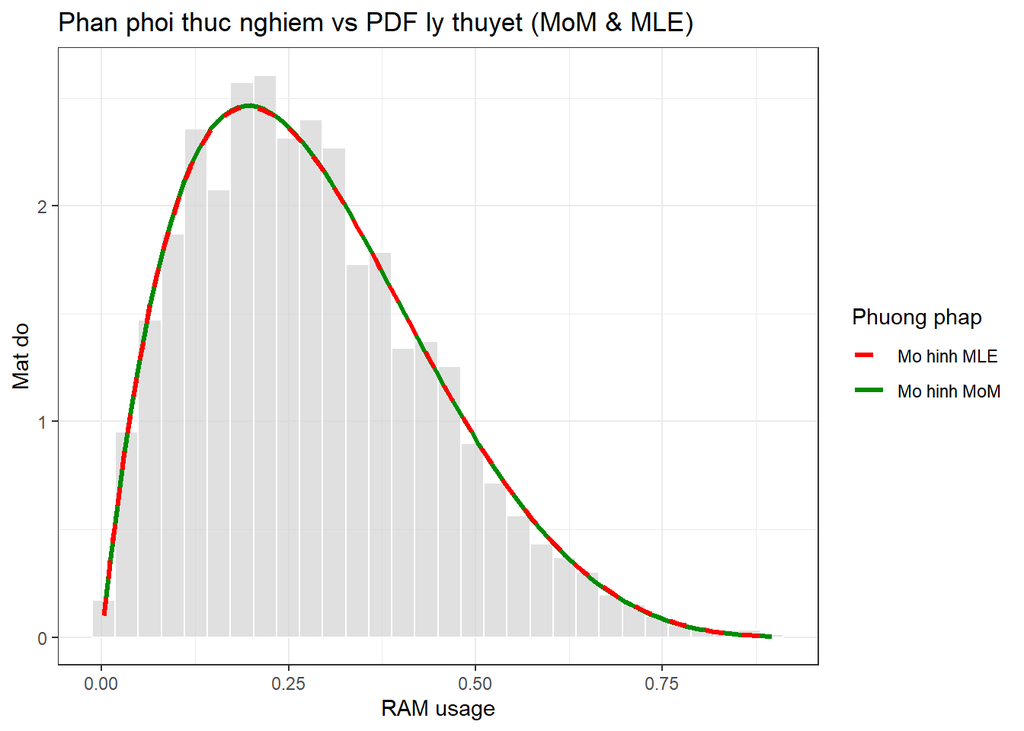

```r
# Histogram ty le RAM va PDF
ggplot(final_data_beta, aes(x = ram_usage)) +
  geom_histogram(aes(y = after_stat(density)), bins = 30, fill = "lightgrey", color = "white", alpha = 0.7) +
  stat_function(fun = dbeta, args = list(shape1 = alpha_mom, shape2 = beta_mom),
                aes(color = "Mo hinh MoM"), linewidth = 1.2, linetype = "solid") +
  stat_function(fun = dbeta, args = list(shape1 = alpha_mle, shape2 = beta_mle),
                aes(color = "Mo hinh MLE"), linewidth = 1.2, linetype = "dashed") +
  scale_color_manual(values = c("Mo hinh MoM" = "green4", "Mo hinh MLE" = "red")) +
  labs(title = "Phan phoi thuc nghiem vs PDF ly thuyet (MoM & MLE)",
       x = "RAM usage", y = "Mat do", color = "Phuong phap") +
  theme_bw()
```

## 5. Khoảng tin cậy phi tham số

Do phân phối Beta bất đối xứng, trung bình không phản ánh đúng xu hướng tập trung. Hãy lập trình tìm khoảng tin cậy 99% cho giá trị Trung vị (Median) của `ram_usage` bằng phương pháp thống kê thứ tự (Order Statistics) dựa trên hàm `qbinom()`. In ra kết quả cận dưới và cận trên.

```r
n_beta <- length(final_data_beta$ram_usage)
alpha_ci <- 0.01

# Xac dinh chi so thu tu d va u
d <- qbinom(alpha_ci / 2, size = n_beta, prob = 0.5)
u <- qbinom(1 - alpha_ci / 2, size = n_beta, prob = 0.5) + 1

# Sap xep du lieu
sorted_ram <- sort(final_data_beta$ram_usage)

median_lower <- sorted_ram[d]
median_upper <- sorted_ram[u]

cat("Can duoi khoang tin cay 99% (X_d):", median_lower, "\n")
```

```
## Can duoi khoang tin cay 99% (X_d): 0.2532773
```

```r
cat("Can tren khoang tin cay 99% (X_u):", median_upper, "\n")
```

```
## Can tren khoang tin cay 99% (X_u): 0.2732159
```

```r
cat("Trung vi thuc te cua mau:", median(final_data_beta$ram_usage), "\n")
```

```
## Trung vi thuc te cua mau: 0.263368
```